# Project Assignement 1 : Summarizing, Visualizing and Exploring Data

Coder :Edouard Dewaerheijd (i6341571) & Presenter : Vienne Jetten (i6361245, Tutorial Group 3)

2023-11-21

# Introduction

This report presents an exploratory data analysis of a student performance data set. The primary objective is to uncover insights into factors affecting student grades, with a focus on understanding the interplay between various academic and personal factors.

# **Data Import and Setup**

We first started by importing the Student.csv dataset and adding the packages we will need to do so.

```r
student <- read.csv("C:/Users/edewa/OneDrive/maastricht/year 1/Knowledge Discovery and Data Visualization/KDDV/project assignment 1/student.csv")

library(ggplot2) #for graphs
library(corrplot) #for nicer corelation matrices
```

# **Creation of a Random Subset**

A random subset of 600 observations was generated from the dataset for detailed analysis. The seed was set to ensure reproducibility.

```r
set.seed(16)
my_data <- student[sample(nrow(student), size = 600),]
```

# Checking For Missing Data

```r
missing_values <- sapply(my_data, function(x) sum(is.na(x)))
missing_values #no missing data :)
```

```
##     school        sex        age    address    famsize    pstatus       medu
##          0          0          0          0          0          0          0
##       fedu       mjob       fjob     reason   guardian traveltime  studytime
##          0          0          0          0          0          0          0
##   failures  schoolsup     famsup       paid activities    nursery     higher
##          0          0          0          0          0          0          0
##   internet   romantic     famrel   freetime      goout       dalc       walc
##          0          0          0          0          0          0          0
##     health   absences         g1         g2         g3
##          0          0          0          0          0
```

# Dataset Understanding

## **Variables :**

```r
str(my_data)
```

```
## 'data.frame':    600 obs. of  33 variables:
##  $ school    : chr  "MS" "GP" "GP" "MS" ...
##  $ sex       : chr  "M" "M" "F" "M" ...
##  $ age       : int  17 16 18 15 16 18 18 17 17 15 ...
##  $ address   : chr  "U" "U" "U" "R" ...
##  $ famsize   : chr  "GT3" "GT3" "GT3" "LE3" ...
##  $ pstatus   : chr  "T" "T" "T" "T" ...
##  $ medu      : int  2 4 2 1 4 4 4 4 2 4 ...
##  $ fedu      : int  3 4 1 3 3 2 4 4 2 4 ...
##  $ mjob      : chr  "other" "services" "other" "at_home" ...
##  $ fjob      : chr  "services" "services" "other" "other" ...
##  $ reason    : chr  "home" "course" "course" "reputation" ...
##  $ guardian  : chr  "father" "mother" "other" "father" ...
##  $ traveltime: int  2 1 2 3 1 1 1 2 1 1 ...
##  $ studytime : int  2 1 3 1 3 2 2 3 3 4 ...
```

[output cut: 19 more lines]

The student dataset contains 33 variables. The variables are almost all categorical, with a couple of exceptions that we will come back to later when we will be binning them.

## **Target Variable:**

The most appropriate target variables for assessing students’ academic performance would be G1, G2, and G3, as they represent their grades for the three periods of the academic year. A correlation matrix was employed to evaluate the level of correlation between these variables.

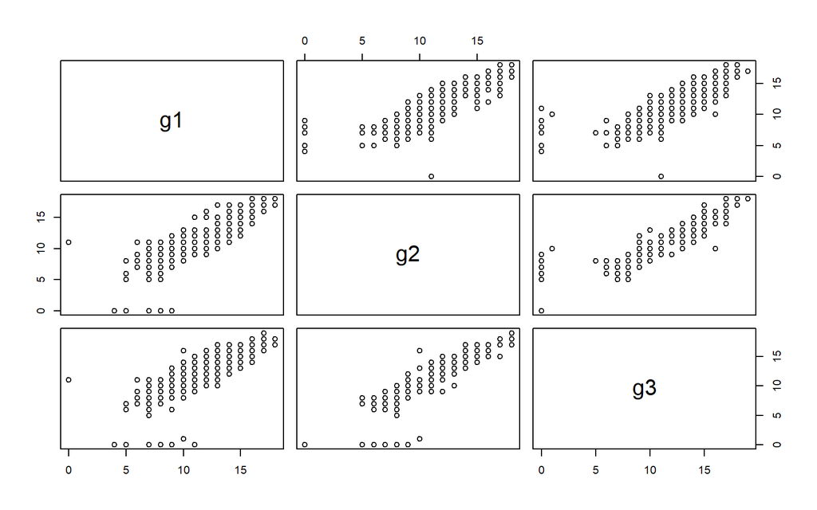

```r
correlation <- cbind(g1 = my_data$g1,
                     g2 = my_data$g2,
                     g3 = my_data$g3)

pairs(correlation) #correlation matrice scater plot
```

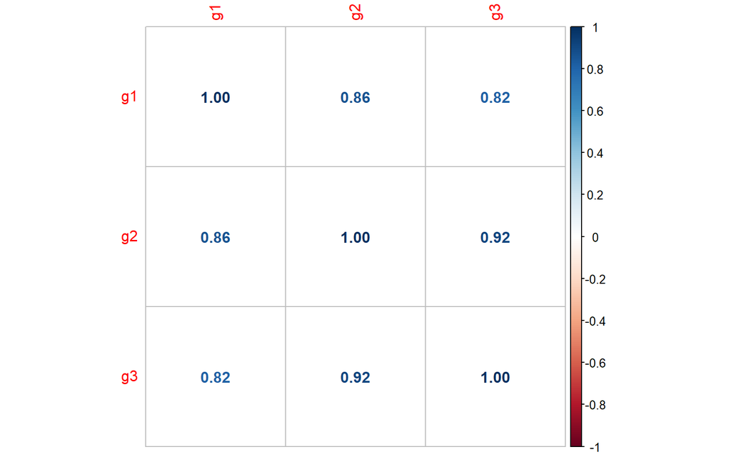

```r
M = cor(correlation)
corrplot(M, method = 'number')
```

We can clearly notice that there is a big correlation between G1, G2, and G3. This means that students have consistently similar grades. For the next part, I chose to average the three variables as it would represent the student’s global performance all along the year. To do so, I used this code:

```r
my_data$grade_mean <- rowMeans(my_data[, c("g1", "g2", "g3")])
```

Here are a couple of stats and a graph of the mean grade variable:

```r
summary(my_data$grade_mean)
```

```
##    Min. 1st Qu.  Median    Mean 3rd Qu.    Max.
##   1.333  10.000  11.667  11.582  13.333  18.000
```

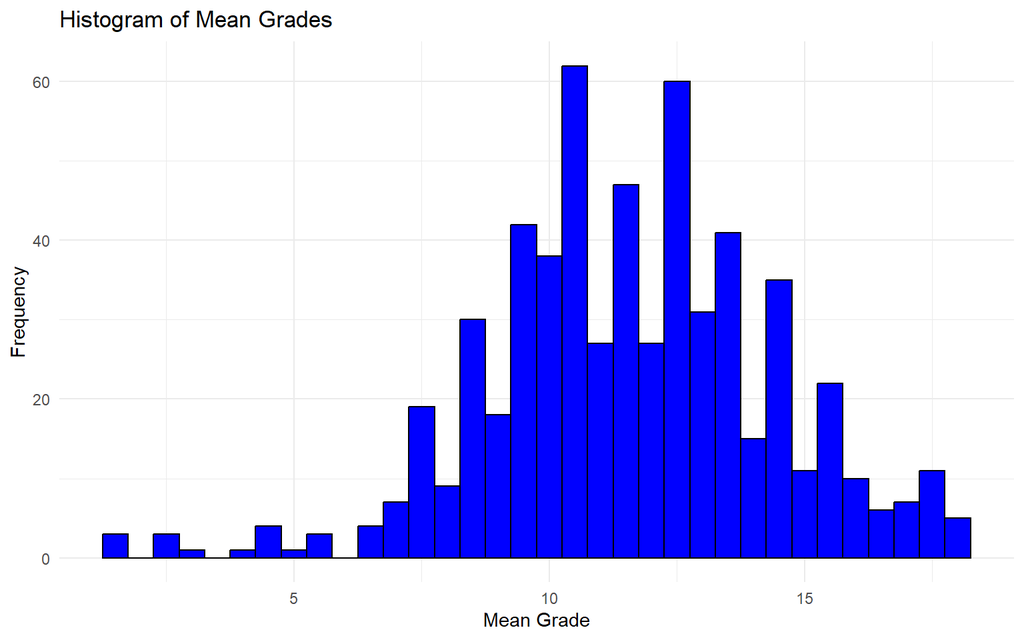

```r
ggplot(my_data, aes(x = my_data$grade_mean)) +
  geom_histogram(binwidth = 0.5, fill = "blue", color = "black") +
  labs(title = "Histogram of Mean Grades", x = "Mean Grade", y = "Frequency") +
  theme_minimal()
```

```r
my_data$pass_fail = ifelse(my_data$grade_mean > 10, "Pass", "Fail")
summary.table.pass_faile <- table(my_data$pass_fail)
summary.table.pass_faile
```

```
##
## Fail Pass
##  183  417
```

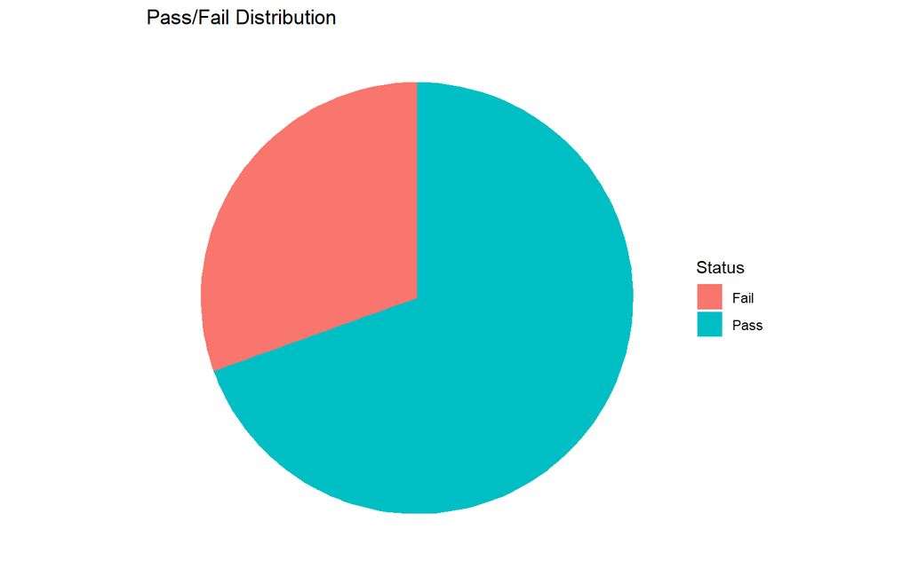

```r
#lets add a pie chart as well
#creating a pass/fail a pie chart using ggplot :
pass_fail_dataframe <- as.data.frame(summary.table.pass_faile)

ggplot(pass_fail_dataframe, aes(x = "", y = Freq, fill = Var1)) +
  geom_bar(width = 1, stat = "identity") +
  coord_polar("y", start = 0) +
  labs(fill = "Status", title = "Pass/Fail Distribution") +
  theme_void()
```

We have now established that our target variable is ‘Pass/Fail’. Let’s determine what factors affect this variable.

# **Outliers**

For outliers, let’s start by creating a function that will permit us to create boxplots easily.

```r
create_boxplot <- function(data, var) {
  variable_name <- deparse(substitute(var))
  ggplot(data, aes_string(y = variable_name)) +
    geom_boxplot() +
    labs(title = paste("Boxplot of", variable_name),
         x = "",
         y = variable_name) +
    theme_minimal()
}
```

Now let’s run through all our numeric variables and try and spot some outlier.

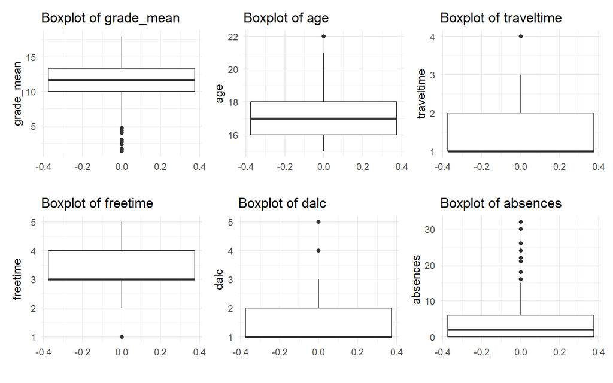

```r
library(patchwork) #libarary makes is possible to have a multiple graphes in a matrice style patch work
p1 <- create_boxplot(my_data, grade_mean)
p2 <-create_boxplot(my_data, age)
p3 <- create_boxplot(my_data, traveltime)
p4 <- create_boxplot(my_data, freetime)
p5 <- create_boxplot(my_data, dalc)
p6 <- create_boxplot(my_data, absences)

graph.this <- (p1 | p2 | p3) / (p4 | p5 | p6)
graph.this
```

Now that we have established that there are outliers, let’s create a function to find the outliers mathematically.

```r
find_outliers <- function(data, var) {

  variable_name <- deparse(substitute(var)) #transfor into string

  var_data <- data[[variable_name]]#extract data

  # Calculate IQR
  Q1 <- quantile(var_data, 0.25)
  Q3 <- quantile(var_data, 0.75)
  IQR <- Q3 - Q1

  lower_bound <- Q1 - 1.5 * IQR
  upper_bound <- Q3 + 1.5 * IQR
  outliers <- var_data[var_data < lower_bound | var_data > upper_bound]

  cat(variable_name, ":")
  return(unique(outliers))
}
```

Finding the outliers:

```r
find_outliers(my_data, grade_mean)
```

```
## grade_mean :
```

```
## [1] 4.666667 3.000000 4.000000 2.333333 4.333333 1.333333 2.666667 1.666667
```

```r
find_outliers(my_data, age)
```

```
## age :
```

```
## [1] 22
```

```r
find_outliers(my_data, traveltime)
```

```
## traveltime :
```

```
## [1] 4
```

```r
find_outliers(my_data, freetime)
```

```
## freetime :
```

```
## [1] 1
```

```r
find_outliers(my_data, dalc)
```

```
## dalc :
```

```
## [1] 5 4
```

```r
find_outliers(my_data, absences)
```

```
## absences :
```

```
## [1] 18 16 32 24 21 22 26 30
```

# **Finding Relationships In The Data**

**Categorical variables** let’s start with finding relationships between categorical variables and our target variable. To do so we created a barplot graph to assess visually if there is a correlation between the variables.

```r
#normalized bar plot function
barplot.norm <- function(data, y) {
  variable_name <- deparse(substitute(y))
  graph_title <- paste("Pass/Fail Distribution by", variable_name)
  ggplot(data, aes_string(x = variable_name, fill = "pass_fail")) +
    geom_bar(position = "fill") +
    labs(title = graph_title,
         x = variable_name,
         y = "Percentage") +
    theme_minimal() +
    scale_fill_brewer(palette = "Set1")
}

#bar plot function
barplot.func <- function(data, y) {
  variable_name <- deparse(substitute(y))
  graph_title <- paste("Pass/Fail Distribution by", variable_name)
  ggplot(data, aes_string(x = variable_name, fill = "pass_fail")) +
    geom_bar(position = "stack") +
    labs(title = graph_title,
         x = variable_name,
         y = "count") +
    theme_minimal() +
    scale_fill_brewer(palette = "Set1")
}
```

We also created a frequency table function to find out the percentages easily after finding graphs that stood out.

```r
perc.table <- function(data, y) {
  # Convert the variable name to a string
  y_var <- deparse(substitute(y))

  # Create a contingency table
  counts_table <- table(data[[y_var]], data$pass_fail)
  # Calculate percentages
  percent_table <- prop.table(counts_table, 1) * 100

  return(percent_table)
}
perc.table(my_data, sex) #test to see if the function works
```

```
##
##         Fail     Pass
##   F 25.49575 74.50425
##   M 37.65182 62.34818
```

## graphs

**School**

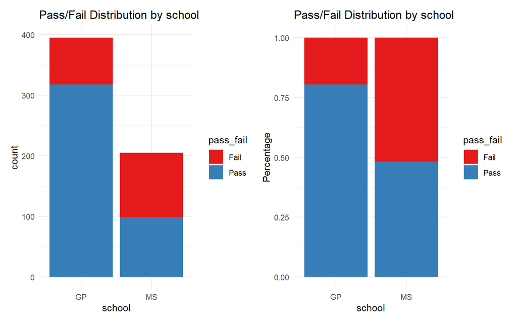

```r
p1 <- barplot.func(my_data, school)
p2 <- barplot.norm(my_data, school)

graph.this <- ( p1 | p2 )
graph.this
```

```r
perc.table(my_data, school)
```

```
##
##          Fail     Pass
##   GP 19.49367 80.50633
##   MS 51.70732 48.29268
```

The ‘GP’ school has a significantly higher pass rate (30% higher) compared to ‘MS’, indicating a discrepancy between the two schools. Further investigation is needed to explore the factors contributing to this difference.

**Higher**

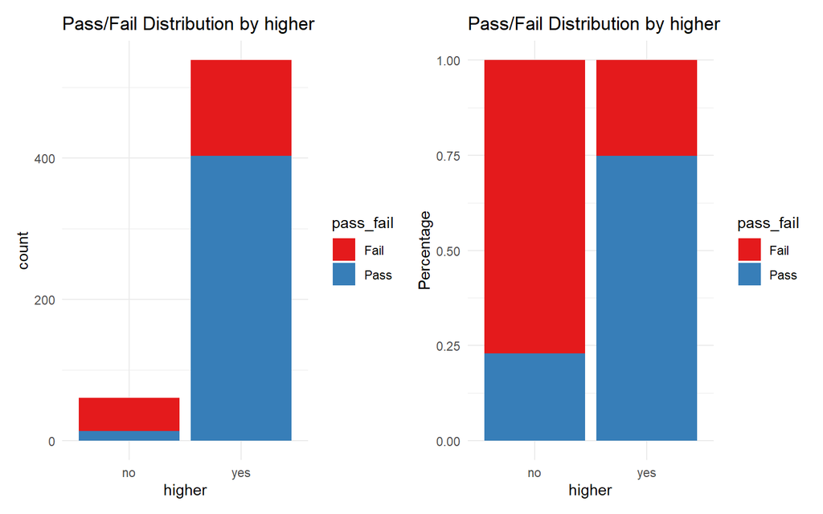

```r
p1 <- barplot.func(my_data, higher)
p2 <- barplot.norm(my_data, higher)

graph.this <- ( p1 | p2 )
graph.this
```

```r
perc.table(my_data, higher)
```

```
##
##           Fail     Pass
##   no  77.04918 22.95082
##   yes 25.23191 74.76809
```

The data shows a correlation between a student’s interest in higher education and their likelihood of passing. Students who express an interest in higher education pass at a significantly higher rate (over 50% more). This suggests that motivation and future aspirations are closely linked to academic performance.

**Address**

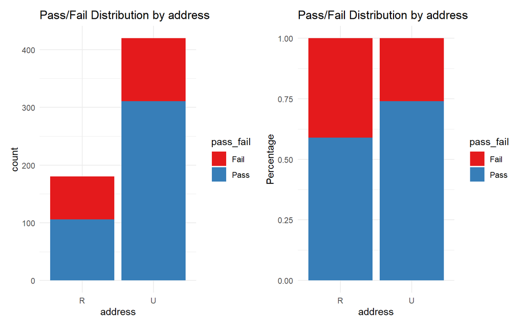

```r
p1 <- barplot.func(my_data, address)
p2 <- barplot.norm(my_data, address)

graph.this <- ( p1 | p2 )
graph.this
```

```r
perc.table(my_data, address)
```

```
##
##         Fail     Pass
##   R 41.11111 58.88889
##   U 25.95238 74.04762
```

Urban students have a pass rate of approximately 74%, while rural students show a lower pass rate of nearly 59%. This could mean that there is a difference between education level in urban/rural schools.

**Mothher education**

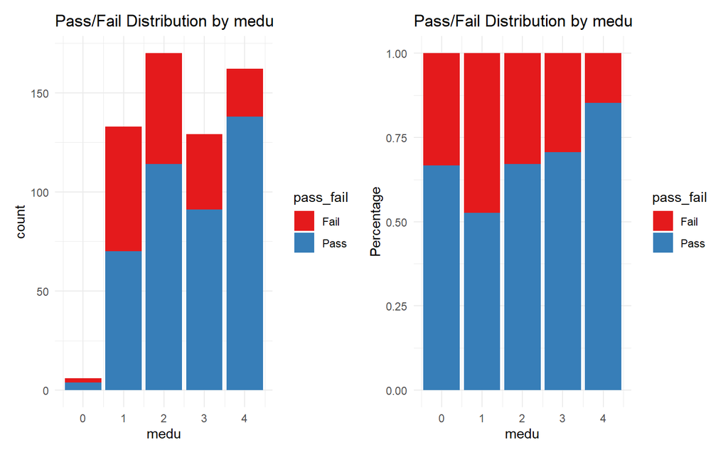

```r
p1 <- barplot.func(my_data, medu)
p2 <- barplot.norm(my_data, medu)

graph.this <- ( p1 | p2 )
graph.this
```

```r
perc.table(my_data, medu)
```

```
##
##         Fail     Pass
##   0 33.33333 66.66667
##   1 47.36842 52.63158
##   2 32.94118 67.05882
##   3 29.45736 70.54264
##   4 14.81481 85.18519
```

Students with mothers who have higher education levels (level 4) show an 85% pass rate, compared to a 67% pass rate for those whose mothers have no education (level 0), suggesting a positive correlation between a mother’s education level and student success.

**Guardian**

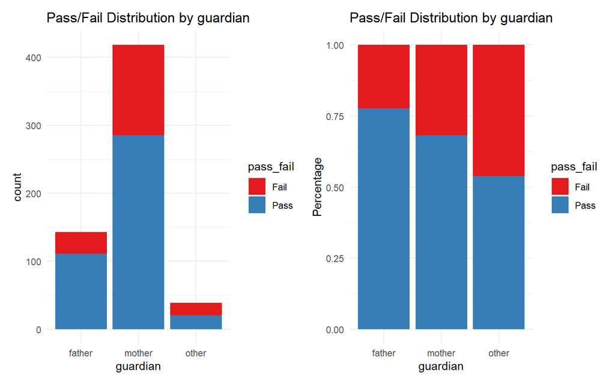

```r
p1 <- barplot.func(my_data, guardian)
p2 <- barplot.norm(my_data, guardian)

graph.this <- ( p1 | p2 )
graph.this
```

```r
perc.table(my_data, guardian)
```

```
##
##              Fail     Pass
##   father 22.37762 77.62238
##   mother 31.81818 68.18182
##   other  46.15385 53.84615
```

Students with fathers as guardians show the highest pass rate at approximately 78%, while those with other guardians have the lowest at around 54%, suggesting that parental involvement could be a significant factor in academic success.

## numerical variables :

### Let’s start off with a couple of bar plots of numerical variables that stand out and binning them when necessary:

**Free Time**

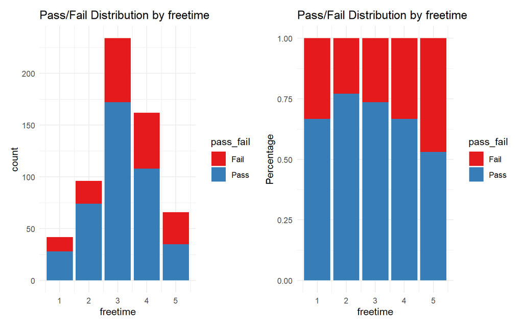

```r
p1 <- barplot.func(my_data, freetime)
p2 <- barplot.norm(my_data, freetime)

graph.this <- ( p1 | p2 )
graph.this
```

```r
perc.table(my_data, freetime)
```

```
##
##         Fail     Pass
##   1 33.33333 66.66667
##   2 22.91667 77.08333
##   3 26.49573 73.50427
##   4 33.33333 66.66667
##   5 46.96970 53.03030
```

**Work day alcool consumption**

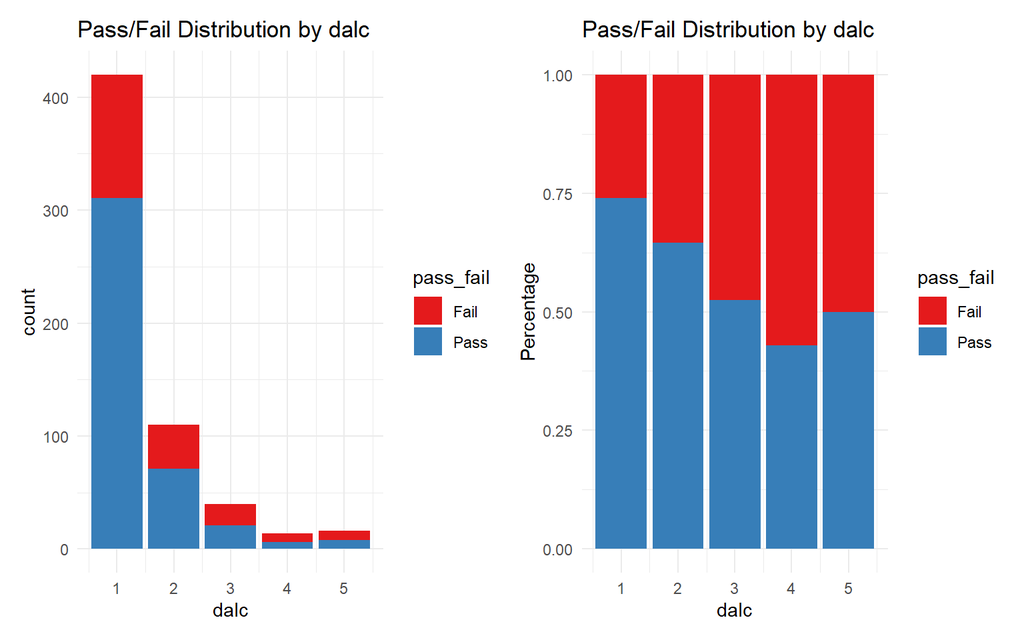

```r
p1 <- barplot.func(my_data, dalc)
p2 <- barplot.norm(my_data, dalc)

graph.this <- ( p1 | p2 )
graph.this
```

Let’s try and bin this numerical variable to learn more about the effect of workday alcohol consumption on a student passing or failing school.

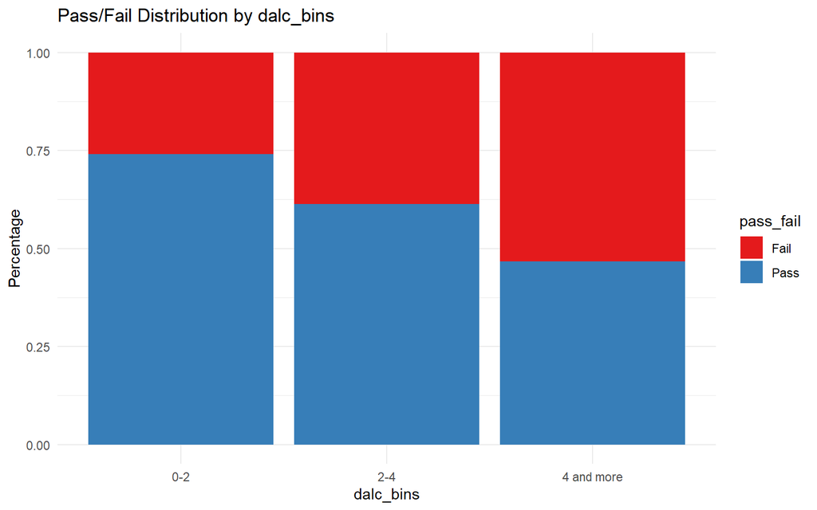

```r
my_data$dalc_bins <- cut(my_data$dalc,
                            breaks = c( 0, 2, 4, Inf),
                            labels = c("0-2", "2-4", '4 and more'),
                            right = FALSE)
barplot.norm(my_data, dalc_bins)
```

After binning we can clearly tell that the more alcohol a student consume the higher the fail rate is. Especialy when a student alcohol level is over 4 at witch the fail rate is over 50%.

**absences**

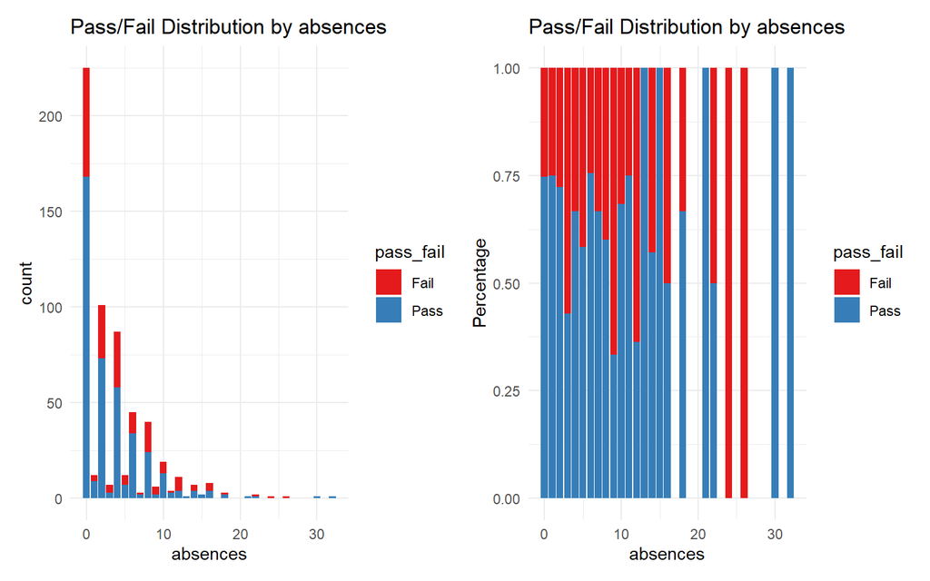

```r
p1 <- barplot.func(my_data, absences)
p2 <- barplot.norm(my_data, absences)

graph.this <- ( p1 | p2 )
graph.this
```

There is a lot of information on these graphs, let’s bin this variable to try and understand what it tells us on the pass/fail ratio and to try and hide the outlines we established in the 8 part of this paper.

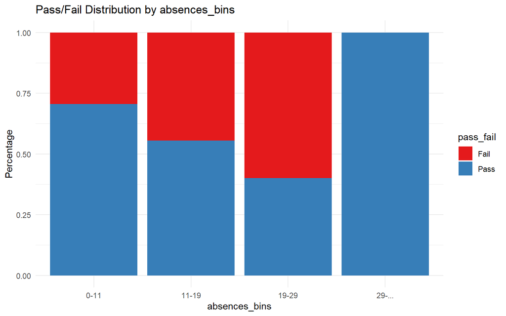

```r
my_data$absences_bins <- cut(my_data$absences,
                            breaks = c( 0, 11, 19, 29, Inf),
                            labels = c("0-11", "11-19", "19-29", "29-..."),
                            right = FALSE)

barplot.norm(my_data, absences_bins)
```

After binning the absences variable we can tell that generally speaking the more a student is absent the higher the fail rate goes, especially between 19-29 absences where over 60% of students fail. We also find out that students with over 29 absences have a 100% pass rate.

### Correlation matrix and scatter plots

To start of the numerical variable analysis I am going to put them all in a correlation matrices to see if we could find any clear relationship between to variables.

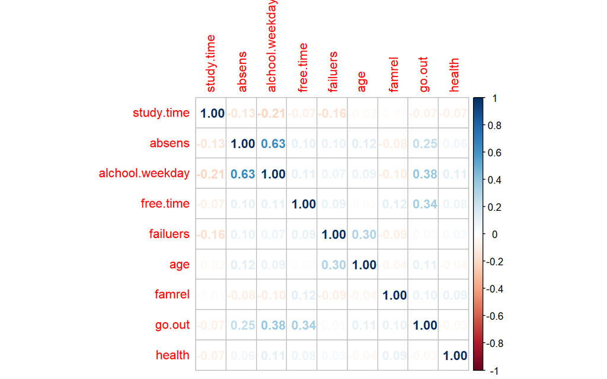

```r
correlation <- cbind(study.time = my_data$studytime,
                     absens = my_data$dalc,
                     alchool.weekday = my_data$walc,
                     alchool.weekend = my_data$g,
                     free.time = my_data$freetime,
                     failuers = my_data$failures,
                     age = my_data$age,
                     famrel = my_data$famrel,
                     go.out = my_data$goout,
                     health = my_data$health)
M = cor(correlation)
corrplot(M, method = 'number')
```

```r
create_scatter_plot <- function(data, var1, var2) {
  # Convert variable names to strings
  var1_name <- deparse(substitute(var1))
  var2_name <- deparse(substitute(var2))

  # Generate the scatter plot
  scatter_plot <- ggplot(data, aes_string(x = var1_name, y = var2_name, color = "pass_fail")) +
    geom_point() +
    labs(title = paste("Scatter Plot of", var1_name, "vs", var2_name),
         x = var1_name,
         y = var2_name) +
    scale_color_manual(values = c("Fail" = "red", "Pass" = "blue")) +
    theme_minimal()

  return(scatter_plot)
}
```

**Graphs that stand out:**

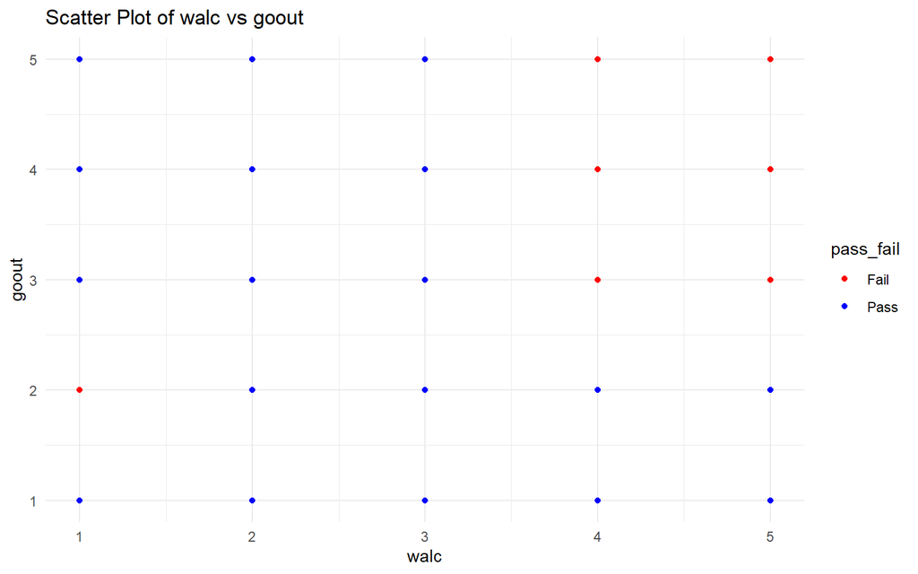

```r
create_scatter_plot(my_data, walc, goout)
```

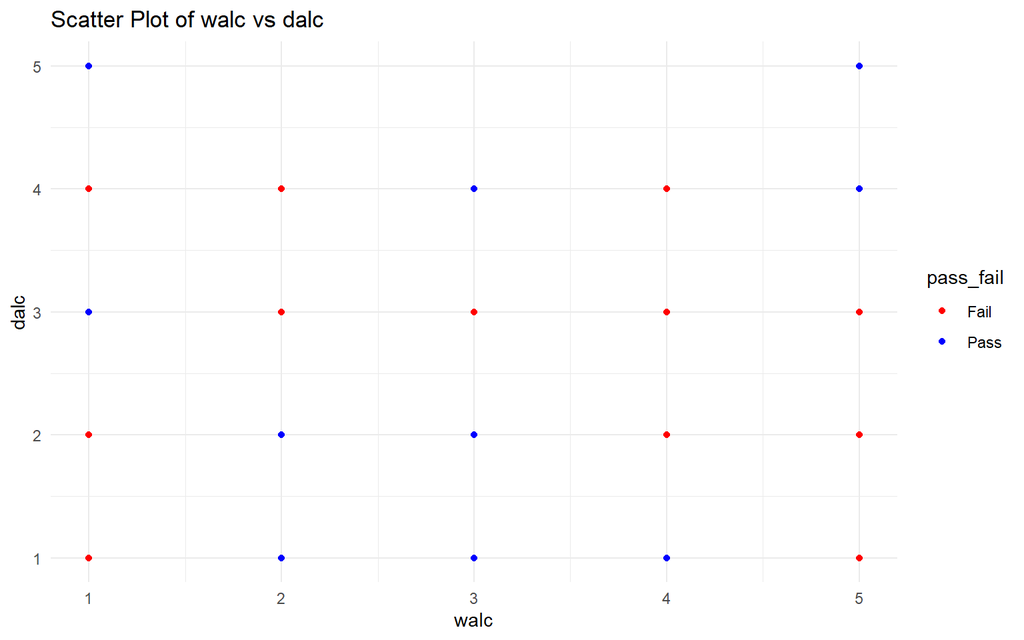

```r
create_scatter_plot(my_data, walc, dalc)
```

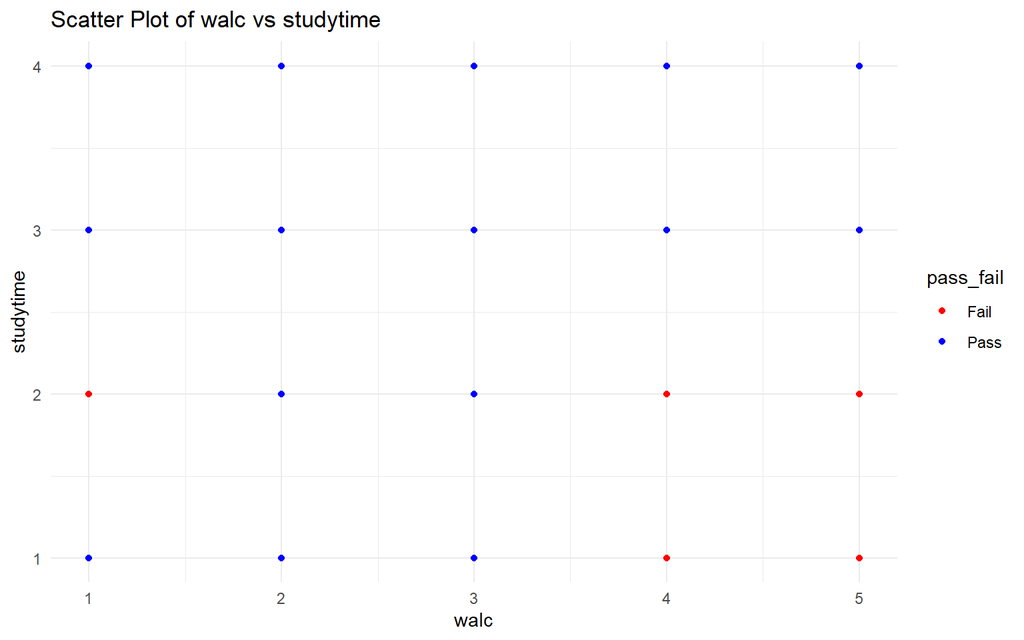

```r
create_scatter_plot(my_data, walc, studytime)
```

Once again we can see that student tend to consume alcohol on the weekend and study across all levels. however we can clearly see that student that consume the most alcohol and study the least tend to fail more.

# Conclusion :

This exploratory analysis examined several key factors influencing student performance in Portugal. Upon recognizing a strong correlation between grades over three periods, we averaged them to reflect the student’s overall performance throughout the year. This approach allowed us to classify students into a binary variable indicating whether their average grade was above or below the passing threshold in Portugal, labeled as ‘pass’ and ‘fail.’

In our numerical variables analysis using a correlation matrix, we proceeded to create scatter plots for variables with the highest correlations. This revealed several insights, for example, increased weekend alcohol consumption and more frequent social outings were correlated with a higher likelihood of failing.

In conclusion, these findings underscore that a student’s environment, lifestyle choices, and the support they receive directly influence their chances of academic success.